# Lab 13

Author

Jonathan Coombs

```r
library(tidyverse)
library(lubridate)
library(DT)
library(viridis)
library(janitor)
library(plotly)
library(respirometry)
library(scales)
library(vegan)
```

## Import and Data Prep

```r
# Define neon_mags_soil

NEON_MAGs_prelim <- read_tsv("/work/pi_bio678_umass_edu/data_NEON/exported_img_bins_Gs0166454_NEON.tsv") |>

  clean_names() |>

  # Add a new column community corresponding to different communities names in the genome_name
  mutate(community = case_when(
    str_detect(genome_name, "Freshwater sediment microbial communities") ~ "Freshwater sediment microbial communitie",
    str_detect(genome_name, "Freshwater biofilm microbial communities") ~ "Freshwater biofilm microbial communities",
    str_detect(genome_name, "Freshwater microbial communities") ~ "Freshwater microbial communities",
    str_detect(genome_name, "Soil microbial communities") ~ "Soil microbial communities",
    TRUE ~ NA_character_
  )) |>

  # Create a column type that is either Freshwater or Soil
  mutate(type = case_when(
    str_detect(genome_name, "Freshwater sediment microbial communities") ~ "Freshwater",
    str_detect(genome_name, "Freshwater biofilm microbial communities") ~ "Freshwater",
    str_detect(genome_name, "Freshwater microbial communities") ~ "Freshwater",
    str_detect(genome_name, "Soil microbial communities") ~ "Soil",
    TRUE ~ NA_character_
  )) |>

  # Get rid of the communities strings
  mutate_at("genome_name", str_replace, "Freshwater sediment microbial communities from ", "") |>
  mutate_at("genome_name", str_replace, "Freshwater biofilm microbial communities from", "") |>
  mutate_at("genome_name", str_replace, "Freshwater microbial communities from ", "") |>
  mutate_at("genome_name", str_replace, "Soil microbial communities from ", "") |>

  # separate site from sample name
  separate(genome_name, c("site","sample_name"), " - ") |>

  # Deal with these unknow fields in the sample name by creating a new column and removing them from the sample name
  mutate(sample_unknown = case_when(
    str_detect(sample_name, ".SS.") ~ "SS",
    str_detect(sample_name, ".C0.") ~ "C0",
    str_detect(sample_name, ".C1.") ~ "C1",
    str_detect(sample_name, ".C2.") ~ "C2",
    TRUE ~ NA_character_
  )) |>

  mutate_at("sample_name", str_replace, ".SS", "") |>
  mutate_at("sample_name", str_replace, ".C0", "") |>
  mutate_at("sample_name", str_replace, ".C1", "") |>
  mutate_at("sample_name", str_replace, ".C2", "") |>


  # Get rid of the the common strings at the end of sample names
  mutate_at("sample_name", str_replace, "-GEN-DNA1", "") |>
  mutate_at("sample_name", str_replace, "-COMP-DNA1", "") |>
  mutate_at("sample_name", str_replace, "-COMP-DNA2", "") |>
  mutate_at("sample_name", str_replace, ".DNA-DNA1", "") |>
  mutate_at("sample_name", str_replace, "_v2", "") |>
  mutate_at("sample_name", str_replace, " \\(version 2\\)", "") |>
  mutate_at("sample_name", str_replace, " \\(version 3\\)", "") |>

# Separate out the taxonomy groups
  separate(gtdb_taxonomy_lineage, c("domain", "phylum", "class", "order", "family", "genus"), "; ", remove = FALSE)

NEON_MAGs_soil <- NEON_MAGs_prelim |>
  filter(type == "Soil") |>
  # separate the Sample Name into Site ID and plot info
  separate(sample_name, c("site_ID","subplot.layer.date"), "_", remove = FALSE,) |>
  # some sample names have 3 fields while others have a fourth field for the quadrant. This code create a field for the quadrant when present and adds na for samples from combined cores.
  extract(
    subplot.layer.date,
    into = c("subplot", "layer", "quadrant", "date"),
    regex = "^([^-]+)-([^-]+)(?:-([^-]+))?-([^-]+)$",
    remove = FALSE
  ) |>
  mutate(quadrant = na_if(quadrant, "")) |>
  select(-subplot.layer.date)

# Define genome_groups_all_means

soilChem <- readRDS("/work/pi_bio678_umass_edu/data_NEON/soilChem.rds")

## This is the path for Jeff's personal computer
# soilChem <- readRDS("../data/NEON_metadata/soilChem.rds")

soilChem$sls_metagenomicsPooling[5,'genomicsSampleID']
```

```
[1] "HARV_013-O-20230704-COMP"
```

```r
soilChem$sls_metagenomicsPooling[5,'collectDate']
```

```
[1] "2023-07-04 19:03:00 UTC"
```

```r
soilChem$sls_metagenomicsPooling$genomicsPooledIDList[5]
```

```
[1] "HARV_013-O-39-20230704|HARV_013-O-41-20230704|HARV_013-O-23-20230704"
```

```r
# View(soilChem$sls_soilChemistry # No soil chemistry data for HARV
soilChem$sls_soilMoisture |>
  filter(sampleID == "HARV_013-O-39-20230704") |>
  select(sampleID, soilMoisture)
```

```
                sampleID soilMoisture
1 HARV_013-O-39-20230704        3.223
```

```r
# split up the pooled list into new columns
genomicSamples <- soilChem$sls_metagenomicsPooling |>
  tidyr::separate(genomicsPooledIDList, into=c("first","second","third"),sep="\\|",fill="right") |>
  dplyr::select(genomicsSampleID,first,second,third)

genSampleExample <- genomicSamples |>
  tidyr::pivot_longer(cols=c("first","second","third"),values_to = "sampleID") |>
  dplyr::select(sampleID,genomicsSampleID) |>
  drop_na()

chemEx <- soilChem$sls_soilMoisture |>
  dplyr::select(sampleID,soilMoisture)

## now combine the tables
combinedTab <- left_join(genSampleExample,chemEx, by = "sampleID") |> drop_na()

soilpH_Example <- soilChem$sls_soilpH %>%
  dplyr::filter(sampleID %in% combinedTab$sampleID) %>%
  dplyr::select(sampleID,soilInWaterpH,soilInCaClpH)

# now join with the existing table
combinedTab_pH <- left_join(combinedTab,soilpH_Example, by = "sampleID")

genome_groups_all_mean <- combinedTab_pH %>%
  group_by(genomicsSampleID) %>%
  {left_join(
    summarize_at(.,vars("soilMoisture"), mean),
    summarize_at(.,vars("soilInWaterpH","soilInCaClpH"), mean_pH)
  )}
```

```r
# Combine data frames, save

tmp <- genome_groups_all_mean |> mutate(sample_name = substr(genomicsSampleID, 1, nchar(genomicsSampleID) - 5))

NEON_soilMAGs_soilChem <- left_join(tmp, NEON_MAGs_soil)

write.csv(NEON_soilMAGs_soilChem,file = "NEON_soilMAGs_soilChem.csv")
```

## Exercises

### ChatGPT Prompt

I attached a .csv file that contains metagenome-assembled genomes and soil data based on the site where these samples were taken. Please look at the .csv file and identify the columns and data types present, then write comprehensive R code that performs taxonomic profiling to find the relative abundance of each phylum across sampling site.

### Generated Code

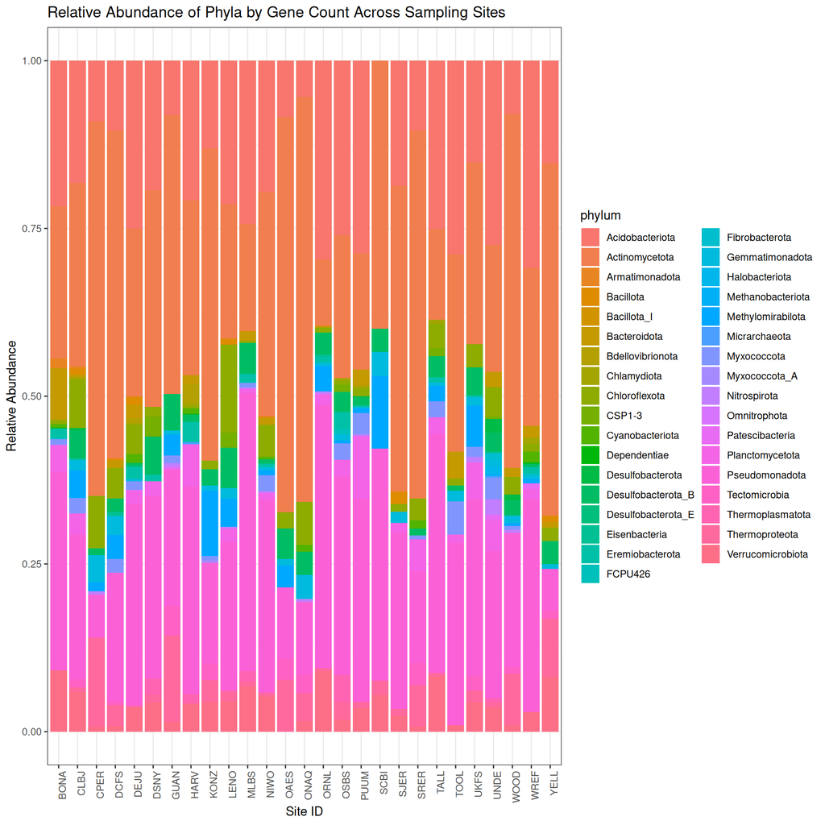

```r
# Load data
df <- NEON_soilMAGs_soilChem

# Ensure taxonomy and site columns exist
df_clean <- df %>%
  filter(!is.na(phylum), !is.na(site_ID))

# Use gene_count as abundance proxy
df_abund <- df_clean %>%
  group_by(site_ID, phylum) %>%
  summarize(total_genes = sum(gene_count, na.rm = TRUE), .groups = "drop")

# Compute relative abundance within each site
df_abund <- df_abund %>%
  group_by(site_ID) %>%
  mutate(rel_abund = total_genes / sum(total_genes)) %>%
  ungroup()

# Plot
ggplot(df_abund, aes(x = site_ID, y = rel_abund, fill = phylum)) +
  geom_col(position = "stack") +
  labs(
    title = "Relative Abundance of Phyla by Gene Count Across Sampling Sites",
    x = "Site ID",
    y = "Relative Abundance"
  ) +
  theme_bw() +
  theme(axis.text.x = element_text(angle = 90, hjust = 1))
```

This graph shows the relative abundance of each phylum per site. From this graph, we can see that each site has a different relative abundance of each phylum, as well as that there are general patterns of phyla common at each site.

```r
# Filter out missing taxonomy or site data
df_clean <- NEON_soilMAGs_soilChem %>%
  filter(!is.na(phylum), !is.na(site_ID))

# Create a site × phylum gene_count abundance table
abund_table <- df_clean %>%
  group_by(site_ID, phylum) %>%
  summarize(total_genes = sum(gene_count, na.rm = TRUE), .groups = "drop") %>%
  pivot_wider(names_from = phylum, values_from = total_genes, values_fill = 0)

# Save site_ID as rownames
abund_mat <- abund_table %>%
  as.data.frame()

rownames(abund_mat) <- abund_mat$site_ID
abund_mat$site_ID <- NULL

# Shannon
shannon <- diversity(abund_mat, index = "shannon")

# Simpson (1 − D)
simpson <- diversity(abund_mat, index = "simpson")

# Species richness (count of nonzero phyla)
richness <- specnumber(abund_mat)

alpha_df <- data.frame(
  site_ID = rownames(abund_mat),
  Shannon = shannon,
  Simpson = simpson,
  Richness = richness
)

alpha_df
```

```
     site_ID  Shannon   Simpson Richness
BONA    BONA 1.832474 0.7979318       15
CLBJ    CLBJ 2.106727 0.8317642       18
CPER    CPER 1.481604 0.6500868       10
DCFS    DCFS 1.695399 0.7074003       14
DEJU    DEJU 1.836882 0.7792207       19
DSNY    DSNY 1.774187 0.7774525       11
GUAN    GUAN 1.751396 0.7562620       12
HARV    HARV 1.843194 0.7852059       17
KONZ    KONZ 1.713526 0.7304306       12
LENO    LENO 2.045432 0.8386402       13
MLBS    MLBS 1.646307 0.7362014       14
NIWO    NIWO 1.738507 0.7618692       18
OAES    OAES 1.451916 0.6237008        9
ONAQ    ONAQ 1.482466 0.6116130       11
ORNL    ORNL 1.661450 0.7375223       14
OSBS    OSBS 1.925891 0.7941230       16
PUUM    PUUM 1.837204 0.7841837       20
SCBI    SCBI 1.452731 0.7035765        7
SJER    SJER 1.411525 0.6865915        9
SRER    SRER 1.544794 0.6608713       11
TALL    TALL 1.863652 0.7809556       14
TOOL    TOOL 1.598102 0.7513748       10
UKFS    UKFS 2.039057 0.8218079       14
UNDE    UNDE 2.187557 0.8317190       22
WOOD    WOOD 1.553901 0.6672624       14
WREF    WREF 1.669542 0.7468529       16
YELL    YELL 1.581056 0.6807276       11
```

```r
bray <- vegdist(abund_mat, method = "bray")
bray
```

```
          BONA      CLBJ      CPER      DCFS      DEJU      DSNY      GUAN
CLBJ 0.2405278
CPER 0.6050824 0.5691770
DCFS 0.4497283 0.2833242 0.4539316
DEJU 0.3601229 0.3214782 0.7225517 0.4151812
DSNY 0.4763588 0.4873685 0.4686614 0.4399355 0.6584368
GUAN 0.5094260 0.4727734 0.2493765 0.3786185 0.6750943 0.3178115
HARV 0.1571589 0.2368496 0.6088730 0.4114327 0.3266298 0.4590908 0.5111383
KONZ 0.4509045 0.3007624 0.4489373 0.1907972 0.5090875 0.3613754 0.2997901
LENO 0.4634645 0.3249388 0.5093954 0.3834979 0.5691500 0.2344886 0.4059180
MLBS 0.2647274 0.3235384 0.6576882 0.4646927 0.5036124 0.3156691 0.4932752
NIWO 0.2840567 0.2303434 0.6468844 0.2952980 0.1604210 0.5818637 0.5868041
OAES 0.5939558 0.5625119 0.1534126 0.4574871 0.7349618 0.4050145 0.2105455
ONAQ 0.5665955 0.4207116 0.2382747 0.3140136 0.6229453 0.4496838 0.2921611
ORNL 0.3132048 0.3166706 0.7125753 0.4854428 0.5399498 0.3845381 0.5416688
OSBS 0.2048599 0.2547533 0.5479728 0.4031045 0.3654022 0.4160662 0.4403649
PUUM 0.4404469 0.4263174 0.7557306 0.5058180 0.2138732 0.7077754 0.6910435
SCBI 0.8369372 0.8197913 0.6410907 0.7764277 0.8970191 0.6410576 0.6379519
SJER 0.4906626 0.5186112 0.3479091 0.4412824 0.6729527 0.1829277 0.2722842
SRER 0.4867361 0.4635544 0.2435562 0.3821799 0.6390087 0.3744075 0.2353277
TALL 0.5030941 0.5046113 0.6343703 0.4749838 0.6723832 0.2439982 0.4738051
TOOL 0.4687962 0.5076760 0.5079061 0.4435604 0.6527861 0.2204799 0.3883395
UKFS 0.2595410 0.1353720 0.5167276 0.2847636 0.4065093 0.4442521 0.4012383
UNDE 0.2512015 0.2344876 0.6070431 0.4265624 0.3073790 0.5124721 0.5357243
WOOD 0.4790437 0.3679949 0.3057482 0.2166016 0.5459683 0.3676511 0.2238452
WREF 0.1982058 0.2730053 0.5400084 0.4152884 0.4379241 0.3525457 0.4559340
YELL 0.5893102 0.5893122 0.2328644 0.5057618 0.7334811 0.3389025 0.3173908
          HARV      KONZ      LENO      MLBS      NIWO      OAES      ONAQ
CLBJ
CPER
DCFS
DEJU
DSNY
GUAN
HARV
KONZ 0.4062722
LENO 0.4612899 0.3688189
MLBS 0.2612939 0.4601154 0.3041168
NIWO 0.2665541 0.3999862 0.4777536 0.4049127
OAES 0.5879584 0.3874058 0.5063490 0.6158683 0.6532502
```

[output cut: 53 more lines]

```
OAES
ONAQ
ORNL
OSBS
PUUM
SCBI
SJER
SRER
TALL
TOOL
UKFS 0.4767598
UNDE 0.5299826 0.2318521
WOOD 0.4137496 0.3576887 0.4849825
WREF 0.3541334 0.2932659 0.2937270 0.4396877
YELL 0.4394744 0.5450017 0.6280006 0.3738595 0.4835142
```

This is a beta-diversity calculation, which is a pairwise metric of the ratio of diversity between two sites. This specific calculation uses Bray-Curtis dissimilarity, which calculates the ratio of dissimilar samples to the total abundance, with a higher value corresponding to higher dissimilarity (i.e. higher relative diversity between sites).

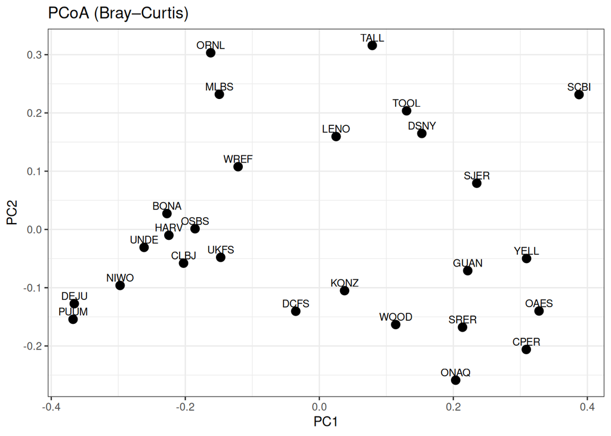

```r
pcoa_res <- cmdscale(bray, eig = TRUE, k = 2)

pcoa_df <- data.frame(
  site_ID = rownames(abund_mat),
  PC1 = pcoa_res$points[,1],
  PC2 = pcoa_res$points[,2]
)

ggplot(pcoa_df, aes(x = PC1, y = PC2, label = site_ID)) +
  geom_point(size = 3) +
  geom_text(vjust = -0.5, size = 3) +
  theme_bw() +
  labs(title = "PCoA (Bray–Curtis)")
```

This is a PCoA graph, showing general local and global distances between different sites, using Bray-Curtis beta diversity measurements as distance and preserving each pairwise distance as much as possible in a 2D space. This graph lets us generally see which sites are clustered near each other and which ones are similar and dissimilar, and is a clear visual metric to interpret the Bray-Curtis beta diversity table.

```r
set.seed(123)
nmds <- metaMDS(abund_mat, distance = "bray", k = 2, trymax = 200)
```

```
Square root transformation
Wisconsin double standardization
*** Best solution repeated 2 times
```

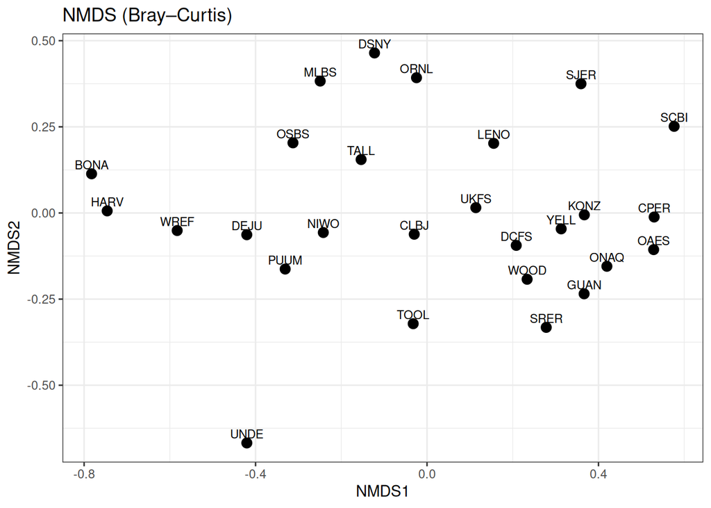

```r
nmds_df <- data.frame(
  site_ID = rownames(abund_mat),
  NMDS1 = nmds$points[,1],
  NMDS2 = nmds$points[,2]
)

ggplot(nmds_df, aes(x = NMDS1, y = NMDS2, label = site_ID)) +
  geom_point(size = 3) +
  geom_text(vjust = -0.5, size = 3) +
  theme_bw() +
  labs(title = "NMDS (Bray–Curtis)")
```

This is an NMDS plot, which is another dimensionality reduction method that can be used alongside a distance metric (still Bray-Curtis) to visualize local and global relationships between sites. In this case, NMDS focuses on preserving rank-order of distances rather than just keeping pairwise distances as close to accurate as possible, which is better at graphing non-linear and complex relationships.